# Estatística no R

# ANOVA de medidas repetidas com grupo controle

Um projeto mais robusto utilizaria que o anterior utilizaria um grupo controle para poder comparar a eficácia do programa entre dois grupos, um que passa pelo programa (grupo experimental) e outro que não passa (grupo controle). Para **simular** essa situação, vamos criar o seguinte **banco de dados fictício**:

### Geração de um banco de dados

```r
# Criação de variáveis, sendo a o grupo controle e b o grupo experimental.

v1a <- round(rnorm(n=50, mean = -1.2, sd = 1.0),digits = 3)
v1b <- round(rnorm(n=50, mean = -1.3, sd = 1.1),digits = 3)
v2a <- round(rnorm(n=50, mean = -1.3, sd = 0.9),digits = 3)
v2b <- round(rnorm(n=50, mean = -0.7, sd = 1.1),digits = 3)
v3a <- round(rnorm(n=50, mean = -1.1, sd = 1.0),digits = 3)
v3b <- round(rnorm(n=50, mean = -0.1, sd = 0.9),digits = 3)
v4a <- round(rnorm(n=50, mean = -1.2, sd = 1.0),digits = 3)
v4b <- round(rnorm(n=50, mean =  0.4, sd = 1.1),digits = 3)
v5a <- round(rnorm(n=50, mean = -1.1, sd = 1.1),digits = 3)
v5b <- round(rnorm(n=50, mean =  0.5, sd = 0.9),digits = 3)

# Junção das variáveis "a" num grupo ctrl
ctrl <- data.frame(v1a,v2a,v3a,v4a,v5a,grupo = "ctrl")

# junção das variáveis "b" num grupo expe
expe <- data.frame(v1b,v2b,v3b,v4b,v5b,grupo = "expe")

# modificação dos nomes das variáveis do grupo expe para ficar igual às variáves do grupo ctrl
# esse passo é necessário para posteriormente juntar esses dois dataframes.
expe <- rename(expe,v1a = v1b,v2a=v2b,v3a=v3b,v4a=v4b,v5a=v5b)

# junção dos dataframes ctrl e expe
df_aov_mr2 <- bind_rows(ctrl,expe)

# transformação da variável grupo em fator
df_aov_mr2$grupo <- as.factor(df_aov_mr2$grupo)

# inserção de uma variável id ao dataframe df_aov_mr2
df_aov_mr2 <- cbind(id = paste("s",1:100,sep = ""),df_aov_mr2)

# renomear as variáveis do dataframe df_aov_mr2 para ficar mais simples
df_aov_mr2 <- rename(df_aov_mr2,v1=v1a,v2=v2a,v3=v3a,v4=v4a,v5=v5a)

# transformação da variável id em fator
# passo necessário para rodar a análise posteriormente
df_aov_mr2$id <- factor(df_aov_mr2$id)
```

### Transformações no banco de dados

Proceder a transformação do banco de dados do formato amplo para o formato longo, de forma semelhante ao que foi feito com o banco de dados `df_aov_mr1`.

```r
# modificação do bd df_aov_mr1 do formato amplo para o formato longo
# usando a função melt() do pacote reshape
df_aov_mr3 <- reshape::melt(df_aov_mr2,
                            id = c("id","grupo"),
                            measure.vars = c("v1","v2","v3","v4","v5"))

# reordenar as colunas pelas variáveis
df_aov_mr3 <- reshape::sort_df(df_aov_mr3,vars = "id")
```

### ANOVA de medidas repetidas

Com o banco de dados no formato longo já é possível rodar o modelo da ANOVA.

```r
# Modelo da ANOVA de medidas repetidas
mod_df_aov_mr3 <- ez::ezANOVA(data = df_aov_mr3, # banco de dados no formato longo
                              dv = value,        # variável dependente
                              wid = id,          # variável que identifica os sujeitos
                              within = variable, # variável intragrupo
                              between = grupo,   # variável entre grupos (ctrl / expe)
                              detailed = TRUE,   # opção para output mais detalhado
                              type = 3)          # opção pelo método da soma dos quadrados

mod_df_aov_mr3    # printar os resultados
```

```
## $ANOVA
##           Effect DFn DFd       SSn       SSd         F            p p<.05
## 1    (Intercept)   1  98 250.97762  84.32283 291.68621 3.905819e-31     *
## 2          grupo   1  98  88.29074  84.32283 102.61151 6.329730e-17     *
## 3       variable   4 392  54.81927 441.71655  12.16230 2.492894e-09     *
## 4 grupo:variable   4 392  52.79351 441.71655  11.71286 5.379851e-09     *
##          ges
## 1 0.32300146
## 2 0.14371873
## 3 0.09437627
## 4 0.09120682
##
## $`Mauchly's Test for Sphericity`
##           Effect         W        p p<.05
## 3       variable 0.8104085 0.016341     *
## 4 grupo:variable 0.8104085 0.016341     *
##
## $`Sphericity Corrections`
##           Effect       GGe        p[GG] p[GG]<.05       HFe        p[HF]
## 3       variable 0.9083497 1.140325e-08         * 0.9476512 5.938869e-09
## 4 grupo:variable 0.9083497 2.300387e-08         * 0.9476512 1.233216e-08
##   p[HF]<.05
## 3         *
## 4         *
```

Os resultados da ANOVA indicam se houve efeito intra e entre grupos, mas não diz em que direção essas diferenças ocorreram. Para isso, é necessário observar as estatísticas descritivas (especialmente as médias) dos grupos.

```r
# construção de um dataframe para visuação das estatísticas descritivas
tab_df_aov_mr2 <-
data.frame(variáveis = names(df_aov_mr2[,2:6]),
           M_ctrl = c(round(mean(df_aov_mr2[df_aov_mr2$grupo == "ctrl",]$v1),digits = 2),
                      round(mean(df_aov_mr2[df_aov_mr2$grupo == "ctrl",]$v2),digits = 2),
                      round(mean(df_aov_mr2[df_aov_mr2$grupo == "ctrl",]$v3),digits = 2),
                      round(mean(df_aov_mr2[df_aov_mr2$grupo == "ctrl",]$v4),digits = 2),
                      round(mean(df_aov_mr2[df_aov_mr2$grupo == "ctrl",]$v5),digits = 2)),
           sdctrl = c(round(mean(df_aov_mr2[df_aov_mr2$grupo == "ctrl",]$v1),digits = 2),
                      round(mean(df_aov_mr2[df_aov_mr2$grupo == "ctrl",]$v2),digits = 2),
                      round(mean(df_aov_mr2[df_aov_mr2$grupo == "ctrl",]$v3),digits = 2),
                      round(mean(df_aov_mr2[df_aov_mr2$grupo == "ctrl",]$v4),digits = 2),
                      round(mean(df_aov_mr2[df_aov_mr2$grupo == "ctrl",]$v5),digits = 2)),
           M_expe = c(round(mean(df_aov_mr2[df_aov_mr2$grupo == "expe",]$v1),digits = 2),
                      round(mean(df_aov_mr2[df_aov_mr2$grupo == "expe",]$v2),digits = 2),
                      round(mean(df_aov_mr2[df_aov_mr2$grupo == "expe",]$v3),digits = 2),
                      round(mean(df_aov_mr2[df_aov_mr2$grupo == "expe",]$v4),digits = 2),
                      round(mean(df_aov_mr2[df_aov_mr2$grupo == "expe",]$v5),digits = 2)),
           sdexpe = c(round(mean(df_aov_mr2[df_aov_mr2$grupo == "expe",]$v1),digits = 2),
                      round(mean(df_aov_mr2[df_aov_mr2$grupo == "expe",]$v2),digits = 2),
                      round(mean(df_aov_mr2[df_aov_mr2$grupo == "expe",]$v3),digits = 2),
                      round(mean(df_aov_mr2[df_aov_mr2$grupo == "expe",]$v4),digits = 2),
                      round(mean(df_aov_mr2[df_aov_mr2$grupo == "expe",]$v5),digits = 2)))
```

[output not shown]

### Representação gráfica

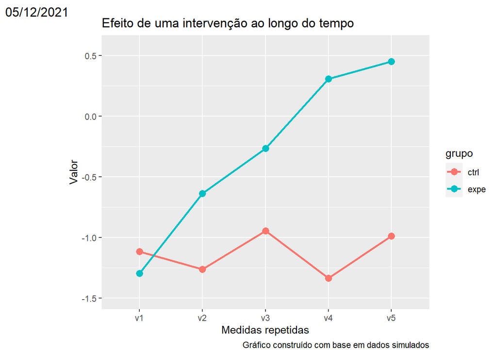

```r
ggplot(data = df_aov_mr3, aes(x = variable, y = value, group = grupo, color = grupo)) +
  geom_line(stat = "summary", size = 1) +
  geom_point(stat = "summary", fun.y = "mean", size = 3) +
  labs(title = "Efeito de uma intervenção ao longo do tempo",
       x = "Medidas repetidas",
       y = "Valor",
       caption = 'Gráfico construído com base em dados simulados',
       tag = "05/12/2021")
```

# Exercícios

1. Utilizando o dataframe `dataset`, verifique se há efeito de gênero (sex) em ansiedade (bai_sum) e depressão (bdi_sum). Observe os dados e escolha a estatística mais apropriada para esse tipo de dado.
2. Em relação ao exercício anterior, represente a ansiedade em tabela e a depressão em forma de gráfico.
3. Utilizando o mesmo dataframe, verifique se há diferenças entre países (country) em ansiedade (bai_sum) e depressão (bdi_sum). Observe os dados e escolha a estatística mais apropriada para esse tipo de dado.
4. Em relação ao exercício anterior, represente a ansiedade em tabela e a depressão em forma de gráfico.
5. Execute o código abaixo para gerar o dataframe `df_ex` e realize uma ANOVA de medidas repetidas com esse dataframe. Note que `df_ex` está no **formato amplo**.

```r
df_ex <- data.frame(id = paste("s",1:80,sep = ""),
                    v1 = round(rnorm(n=80, mean = 20, sd = 3),digits = 2),
                    v2 = round(rnorm(n=80, mean = 22, sd = 3),digits = 2),
                    v3 = round(rnorm(n=80, mean = 26, sd = 3),digits = 2),
                    v4 = round(rnorm(n=80, mean = 27, sd = 3),digits = 2),
                    v5 = round(rnorm(n=80, mean = 27, sd = 3),digits = 2))
```